# LACN Report for Brandeis College

#### 2020-21 LACN Operations Survey

## Introduction

### Enrollment

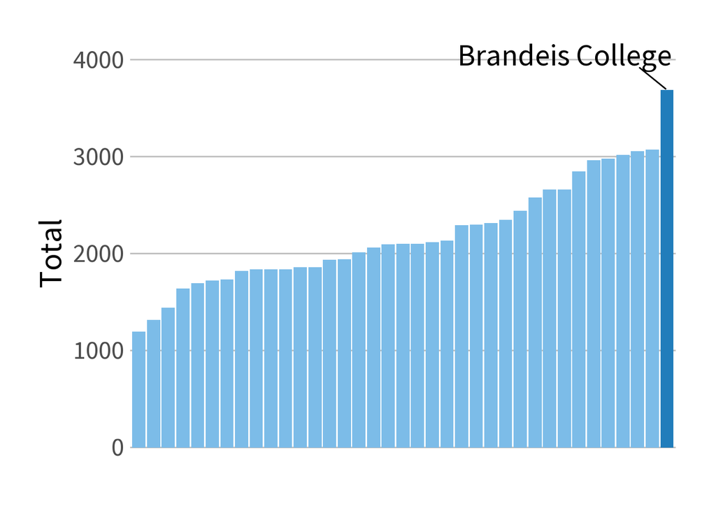

Summary

| N | 37 |
| --- | --- |
| Mean | 2,203 |
| Median | 2,098 |
| Max | 3,688 |
| Min | 1,193 |
| Brandeis College | 3,688 |

### Endowment

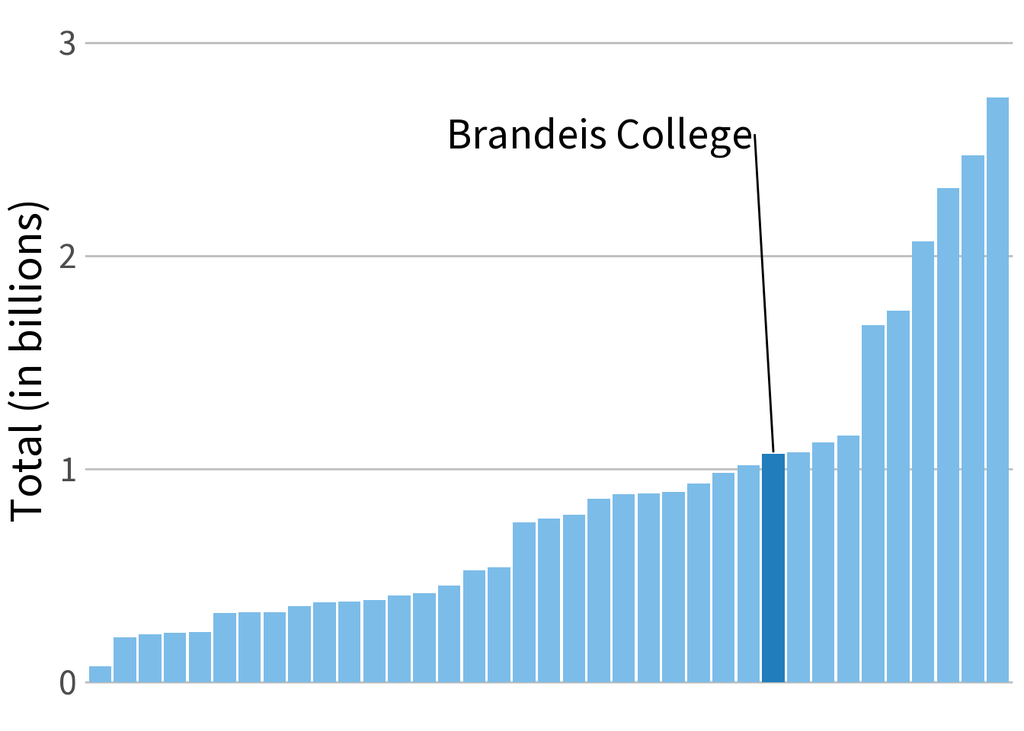

Summary

| N | 37 |
| --- | --- |
| Mean | 865,985,460 |
| Median | 766,909,737 |
| Max | 2,744,103,362 |
| Min | 76,792,235 |
| Brandeis College | 1,073,525,868 |

## Reporting and Staffing

### Reporting Structure

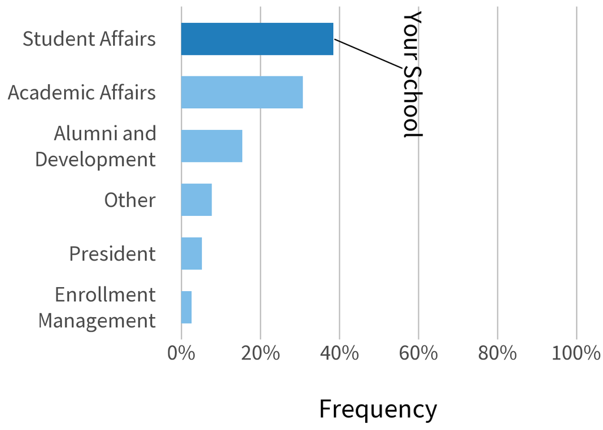

N = 39

### Steps Removed from President’s Office

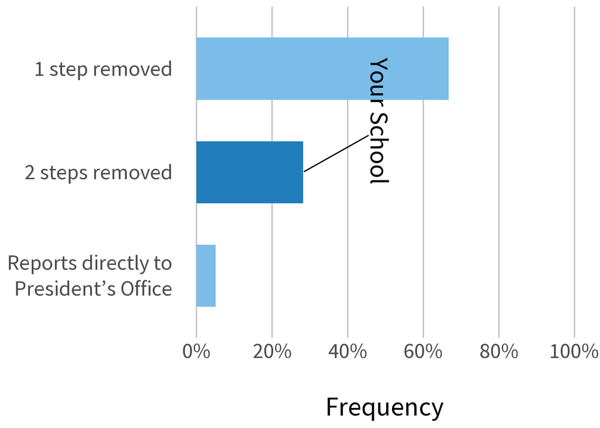

N = 39

### Advisory Boards

Advisory Boards

| To Whom Do You Report? | N | Frequency | Your School |
| --- | --- | --- | --- |
| No Advisory Boards | 21 | 54% |  |
| Alumni | 9 | 23% |  |
| Other | 4 | 10% |  |
| Faculty | 3 | 7.7% | Yes |
| Student | 3 | 7.7% |  |
| Employer | 2 | 5.1% |  |
| Mixed (student, alumni, employer, faculty and/or staff) | 2 | 5.1% |  |

### Performance Metrics

*Relative Importance Ranking (N = 38)*

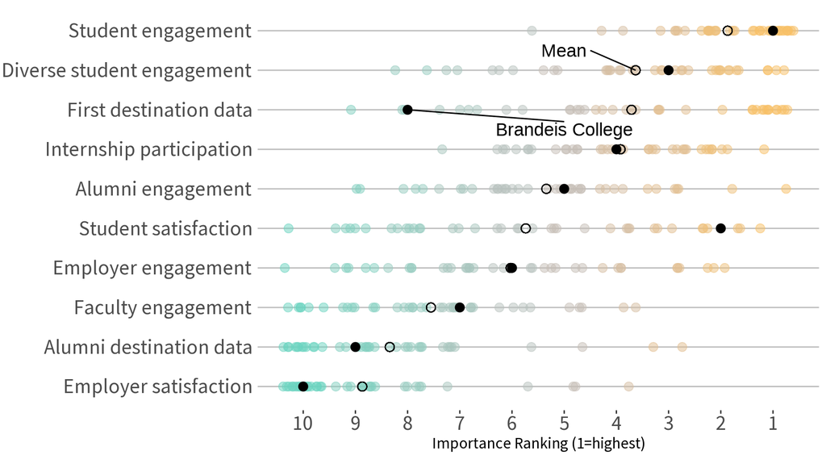

### Student Staff (total)

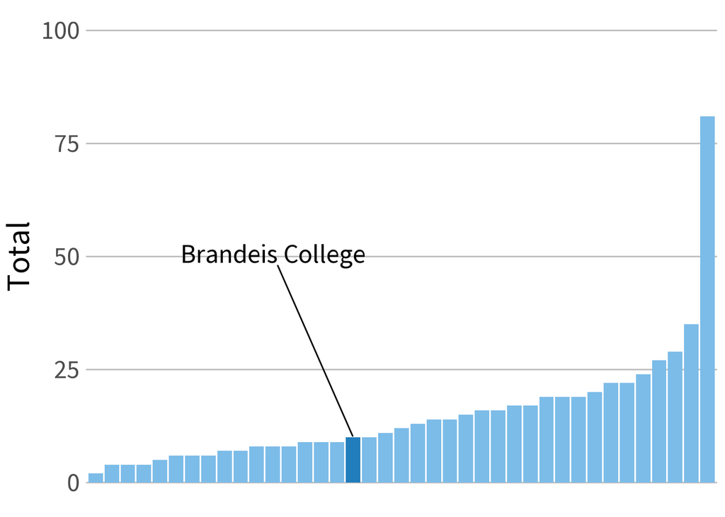

Summary

| N | 39 |
| --- | --- |
| Mean | 15 |
| Median | 12 |
| Max | 81 |
| Min | 2 |
| Brandeis College | 10 |

### Student Staff (paraprofessional)

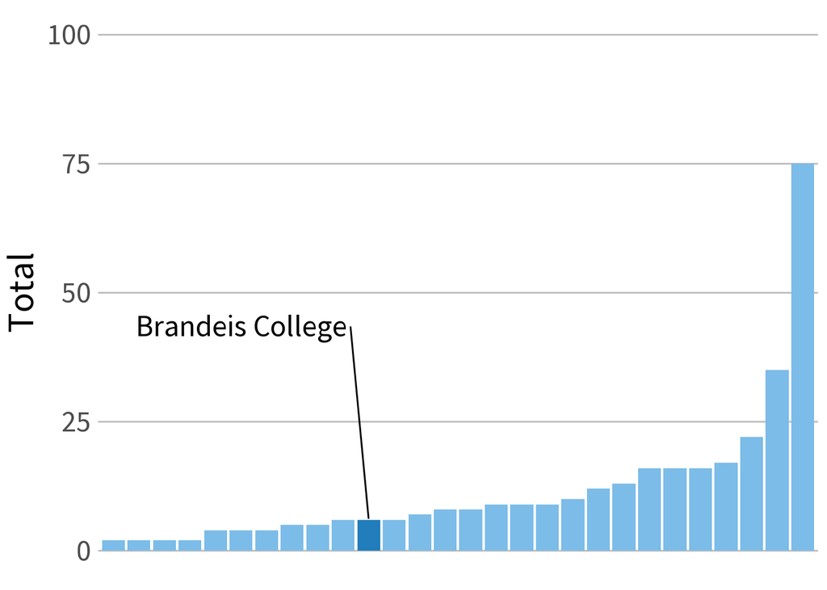

Summary

| N | 28 |
| --- | --- |
| Mean | 12 |
| Median | 8 |
| Max | 75 |
| Min | 2 |
| Brandeis College | 6 |

### Student to Student Staff Ratio

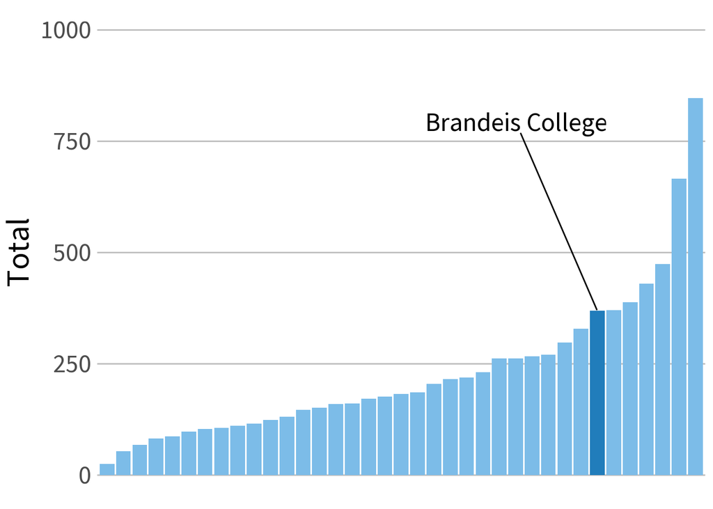

Summary

| N | 37 |
| --- | --- |
| Mean | 231 |
| Median | 182 |
| Max | 848 |
| Min | 25 |
| Brandeis College | 369 |

### Professional (FTE)

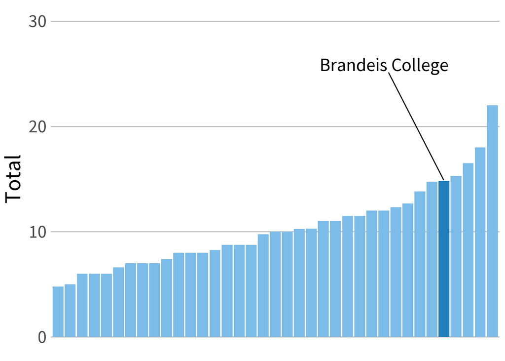

Summary

| N | 37 |
| --- | --- |
| Mean | 10 |
| Median | 10 |
| Max | 22 |
| Min | 5 |
| Brandeis College | 15 |

### Student to Professional Staff (FTE) Ratio

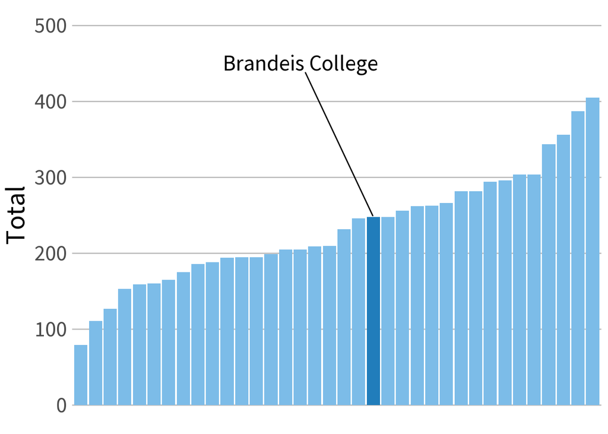

Summary

| N | 36 |
| --- | --- |
| Mean | 233 |
| Median | 221 |
| Max | 405 |
| Min | 79 |
| Brandeis College | 248 |

### Professional Staff: Advising

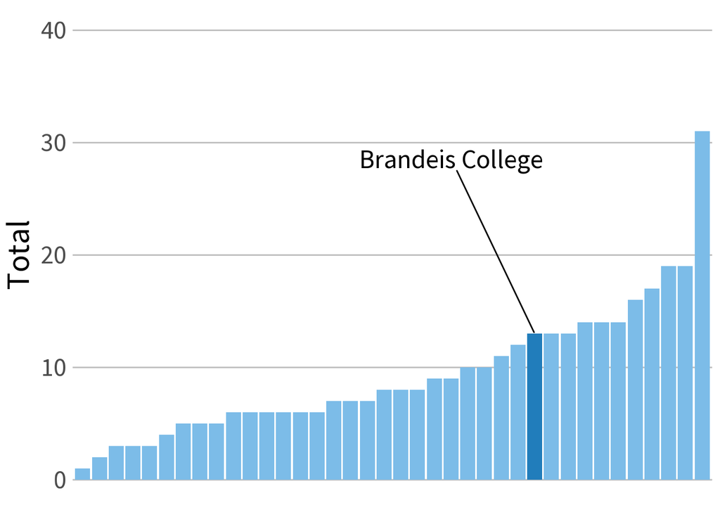

Summary

| N | 38 |
| --- | --- |
| Mean | 9 |
| Median | 8 |
| Max | 31 |
| Min | 1 |
| Brandeis College | 13 |

### Professional Staff: Employer Relations

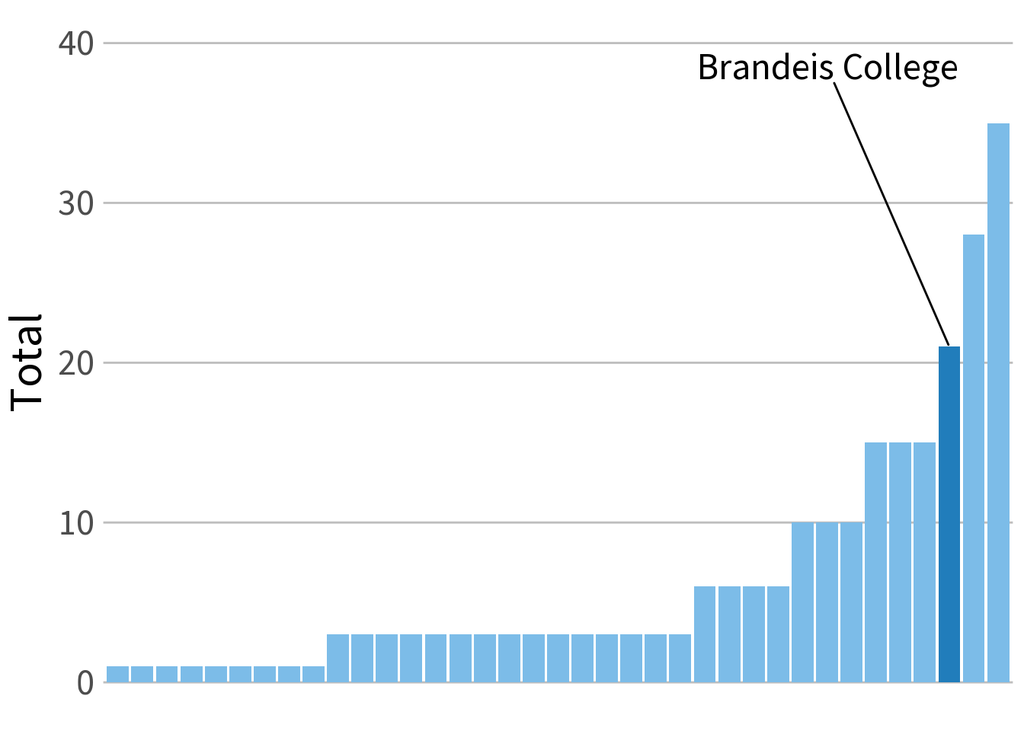

Summary

| N | 37 |
| --- | --- |
| Mean | 6 |
| Median | 3 |
| Max | 35 |
| Min | 1 |
| Brandeis College | 21 |

### Conferences

Conferences Attended by Staff

For write-in responses, see Appendix (n = 39)

| Conferences | N | Frequency | Your School |
| --- | --- | --- | --- |
| National Association of Colleges & Employers (NACE) | 33 | 85% | Yes |
| Small College Career Alliance (SCCA) | 23 | 59% | Yes |
| Regional Associations of Colleges & Employers (e.g., EACE, SWACE) | 21 | 54% |  |
| Health Professions Advising (e.g., National Association of Advisors for the Health Professions) | 19 | 49% | Yes |
| Pre-Law Advising (e.g., NAPLA) | 19 | 49% | Yes |
| Other | 18 | 46% |  |
| National Career Development Association (NCDA) | 12 | 31% | Yes |
| Fellowship Advising (e.g., National Association of Fellowships Advisors) | 6 | 15% | Yes |
| Career Leadership Collective | 6 | 15% |  |
| National Society for Experiential Education (NSEE) | 5 | 13% |  |
| Student Affairs Administrators in Higher Ed (NASPA) | 4 | 10% |  |
| American College Personnel Association (ACPA) | 3 | 7.7% |  |

## Student/Alum Engagement

### Services offered: undergrad

Services Offered to Undergraduates

For write-in responses, see Appendix (n = 39)

| Services | N | Frequency | Your School |
| --- | --- | --- | --- |
| Internship advising/programs/placements | 39 | 100% | Yes |
| Job development, employer relations and recruiting | 38 | 97% | Yes |
| Advising for graduate school admission | 37 | 95% | Yes |
| Pre-law advising | 35 | 90% | Yes |
| Pre-med/health school advising | 23 | 59% | Yes |
| Student on-campus employment | 16 | 41% |  |
| Other | 12 | 31% |  |
| National/international fellowship advising (e.g., Watson, Fulbright) | 7 | 18% | Yes |
| Federal work study | 5 | 13% |  |
| Community service/service-learning | 4 | 10% |  |
| Co-op placements | 1 | 2.6% |  |

### Programs offered: undergrad

Programs Offered to Undergraduates

For write-in responses, see Appendix (n = 39)

| Programs | N | Frequency | Your School |
| --- | --- | --- | --- |
| Employer information sessions | 39 | 100% | Yes |
| Professional staff delivered workshops | 39 | 100% | Yes |
| Student/alumni networking events | 39 | 100% | Yes |
| Alumni and/or parent delivered programs | 37 | 95% | Yes |
| Identity based programming (BIPOC, first generation, LGBTQIA+, etc.) | 37 | 95% | Yes |
| Employer interviews | 36 | 92% | Yes |
| Workshops/presentations to students in academic courses (excluding "career courses") | 36 | 92% | Yes |
| Employer delivered workshops | 35 | 90% | Yes |
| Industry/sector/career community specific events | 35 | 90% | Yes |
| Student staff delivered workshops | 29 | 74% | Yes |
| Career treks/immersion trips (lasting a least one day) | 27 | 69% | Yes |
| Parent/family weekend programs | 26 | 67% | Yes |
| Career fairs (large scale, traditional) | 20 | 51% | Yes |
| Job shadow program | 19 | 49% | Yes |
| Large scale program/event specifically for FIRST YEARS (at least 10% of the class participates) | 17 | 44% | Yes |
| Large scale program/event specifically for SOPHOMORES (at least 10% of the class participates) | 17 | 44% |  |
| Pre-orientation program | 17 | 44% | Yes |
| Career class/program (for credit) | 16 | 41% |  |
| Mentoring program | 15 | 38% |  |
| Large scale program/event specifically for SENIORS (at least 10% of the class participates) | 14 | 36% |  |
| Large-scale practice interview program | 10 | 26% |  |
| Large scale program/event specifically for JUNIORS (at least 10% of the class participates) | 7 | 18% |  |
| Other | 6 | 15% |  |

### Services offered: grad

Services Offered to Grad Students

For write-in responses, see Appendix (n = 8)

| Services | N | Frequency | Your School |
| --- | --- | --- | --- |
| Career Counseling/Advising | 8 | 100% | Yes |
| Job Development, Employer Relations & Recruiting | 6 | 75% | Yes |
| Other | 2 | 25% |  |
| Document Review, On-Campus Job Search | 1 | 12% |  |
| Fellowship Advising | 1 | 12% | Yes |
| Same As What Is Offered To Undergraduates | 1 | 12% |  |

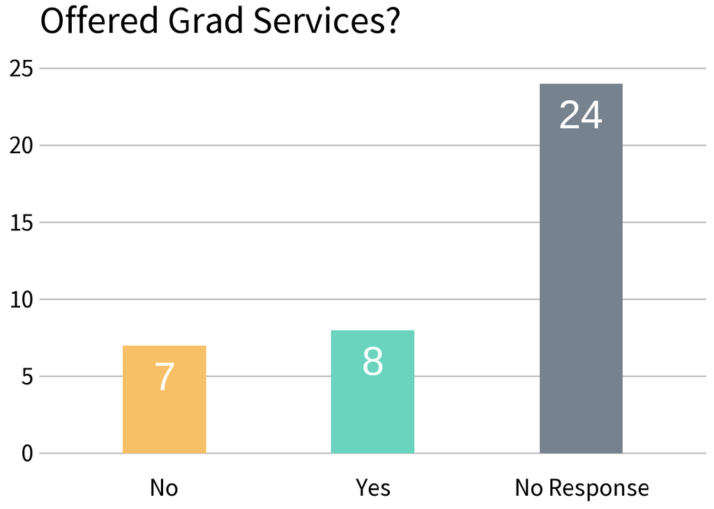

### Services offered: alumni

Services Offered to Alumni

No write-in responses (n = 39)

| Services | N | Frequency | Your School |
| --- | --- | --- | --- |
| Full Service To All Alumni | 17 | 44% | Yes |
| Full Service To "Young" Alumni And Limited Service To Other Alumni | 8 | 21% |  |
| Limited Service To All Alumni | 8 | 21% |  |
| Full Service To "Young" Alumni | 3 | 7.7% |  |
| Limited Service To "Young" Alumni | 3 | 7.7% |  |

All institutions offer alumni services (N = 39)

### Student Engagement by Class Year

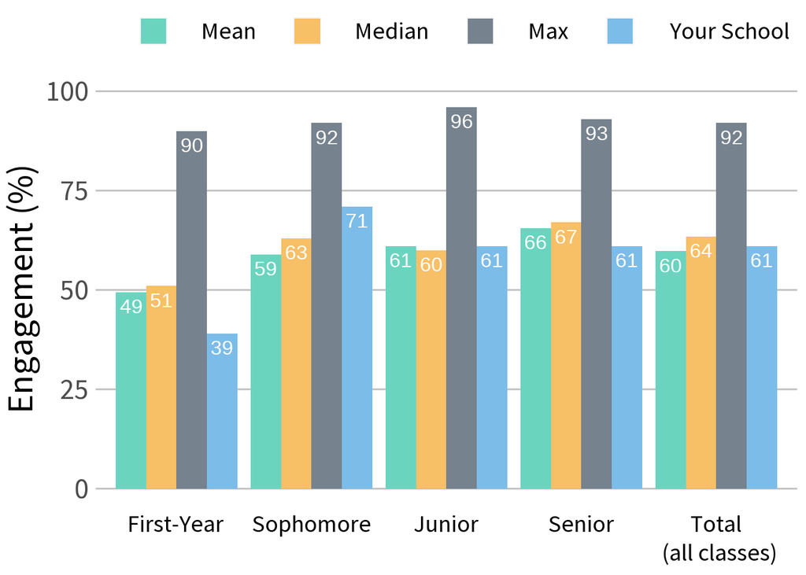

N = 26

Note: Engagement includes appointments w/ professional staff and peer advisors and programs and events

### Student Engagement by Type of Engagement

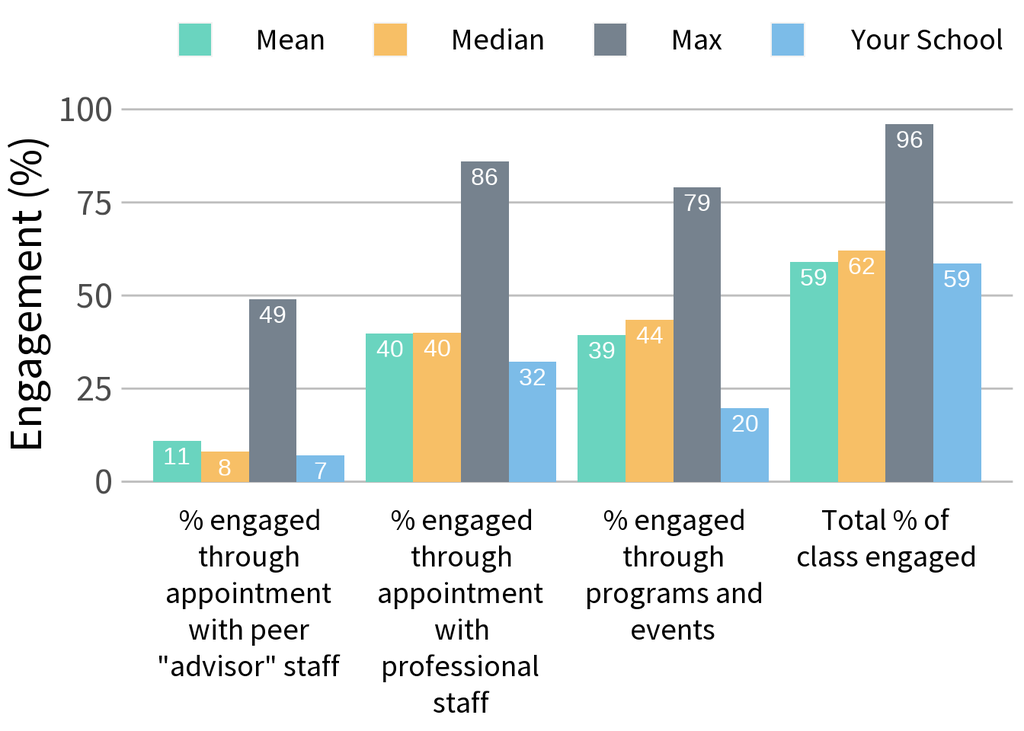

Summary

School Averages

| N | 35 |
| --- | --- |
| Mean | 43 |
| Median | 43 |
| Max | 92 |
| Min | 16 |
| Brandeis College | 29 |

### Professional Staff Appt w/ Students

1. Individual Schools by Class Year
2. Overall Metrics by Class Year

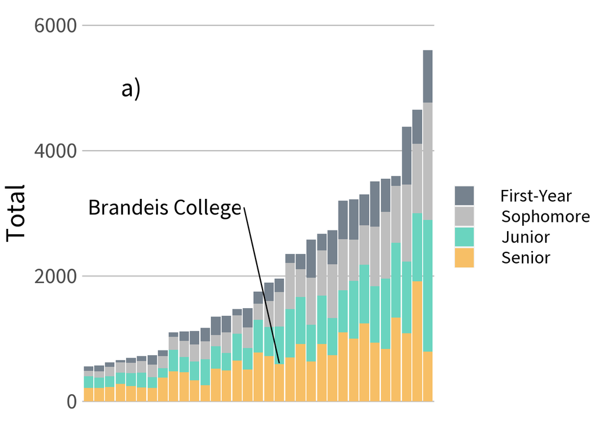

Summary

| N | 33 |
| --- | --- |
| Mean | 2,087 |
| Median | 1,750 |
| Max | 5,602 |
| Min | 557 |
| Brandeis College | 1,958 |

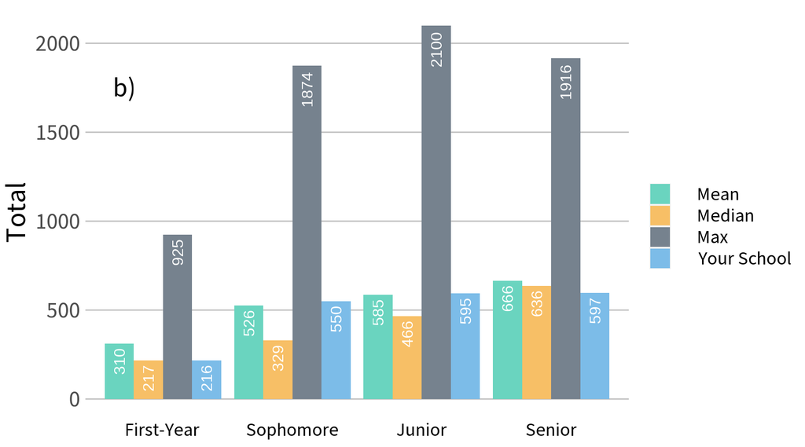

### Professional Staff Appt w/ Alum

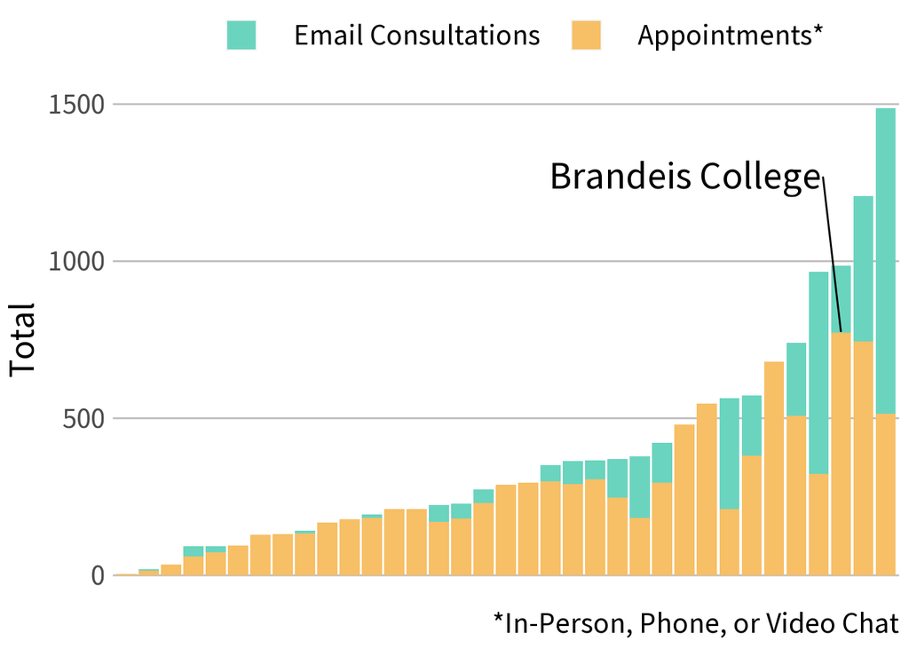

Summary

| N | 35 |
| --- | --- |
| Mean | 385 |
| Median | 289 |
| Max | 1,486 |
| Min | 4 |
| Brandeis College | 985 |

### Professional Staff Appt (+ email) per Total FTE

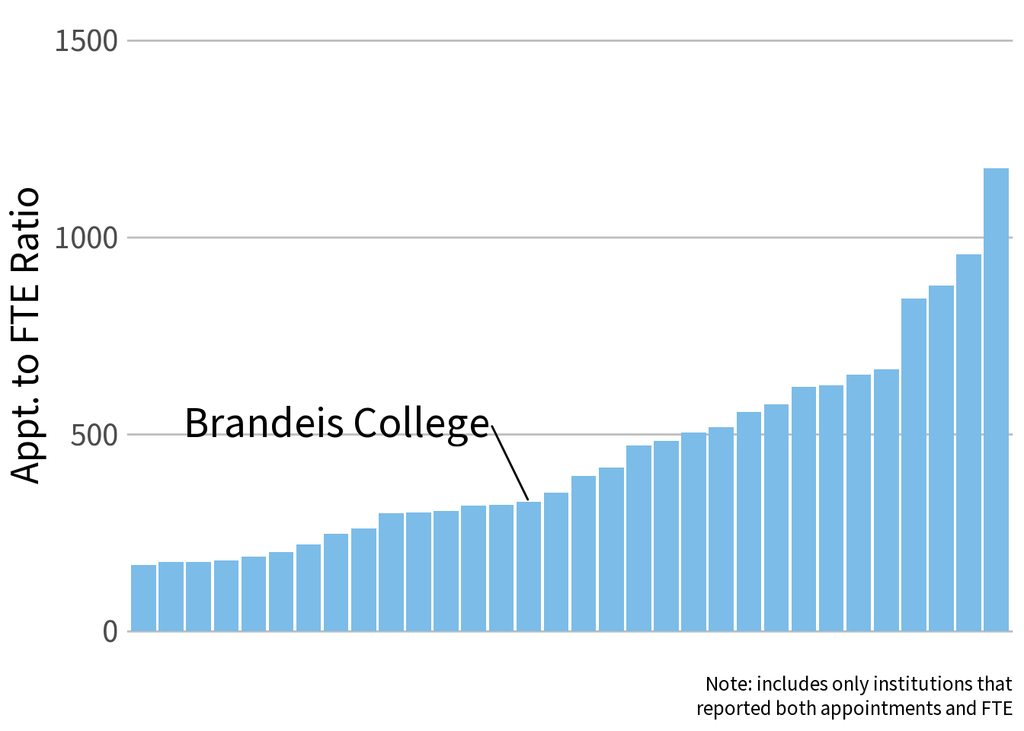

Summary

| N | 32 |
| --- | --- |
| Mean | 450 |
| Median | 373 |
| Max | 1,176 |
| Min | 168 |
| Brandeis College | 330 |

### Experiential Learning Participation

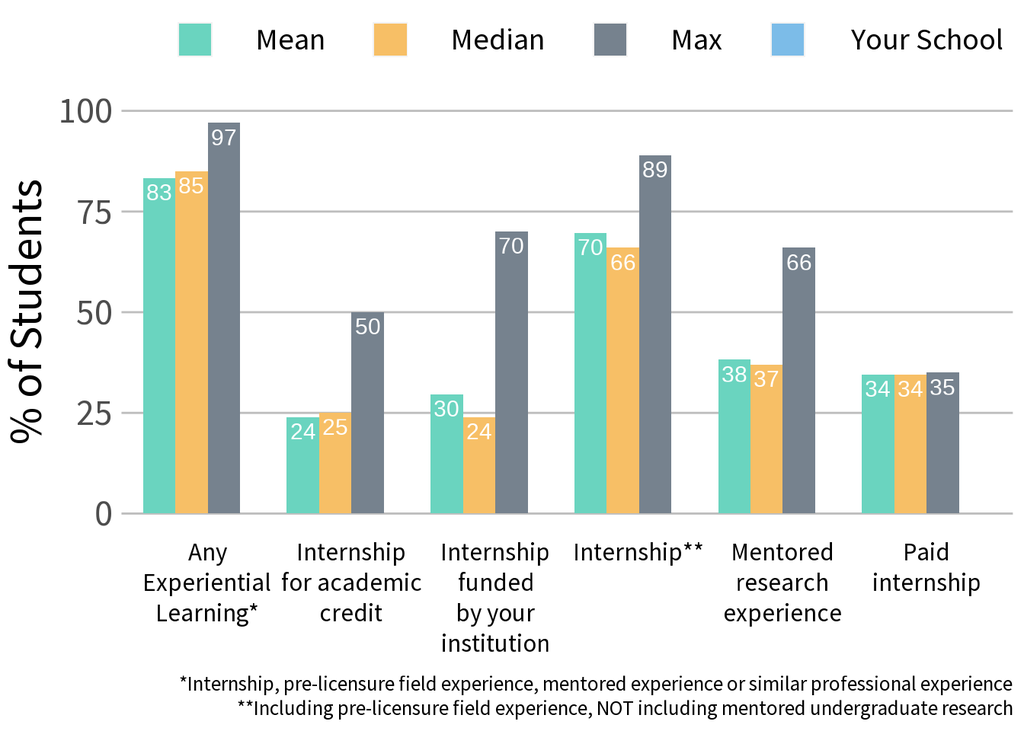

Summary

# of respondents by experience

| Experience | N |
| --- | --- |
| Any Experiential Learning | 9 |
| Internship | 9 |
| Internship for academic credit | 8 |
| Internship funded by your institution | 8 |
| Mentored research experience | 9 |
| Paid internship | 2 |

## Employer Relations

### Info Sessions: Number Offered

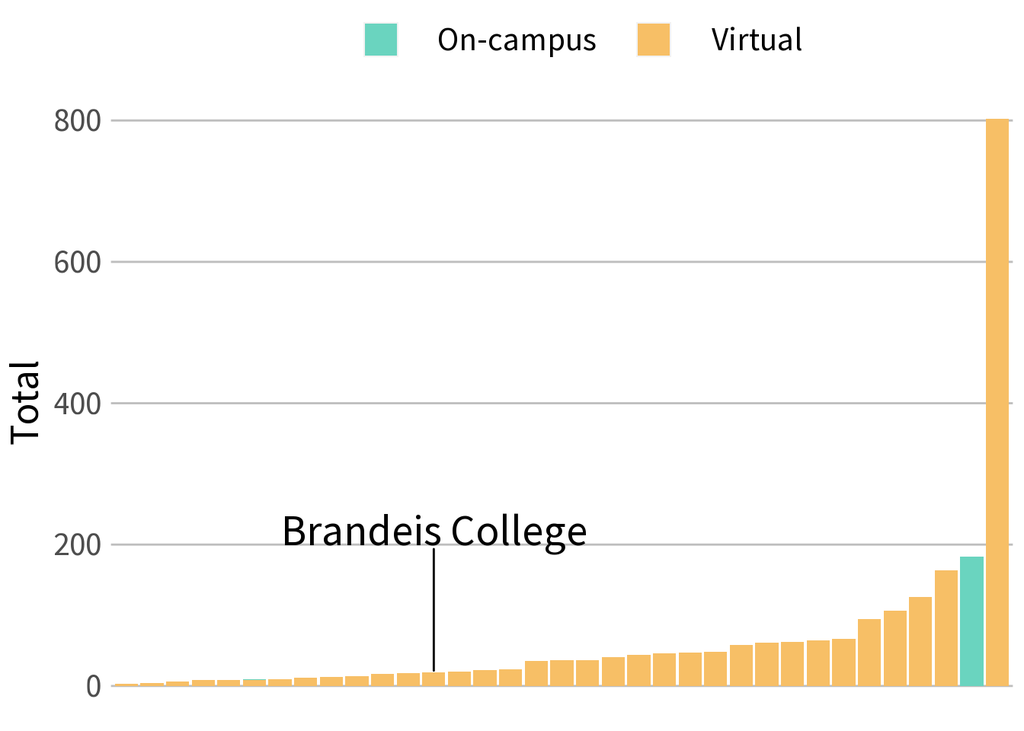

Summary

| N | 35 |
| --- | --- |
| Mean | 67 |
| Median | 36 |
| Max | 802 |
| Min | 3 |
| Brandeis College | 19 |

### Info Sessions: Number of Employers

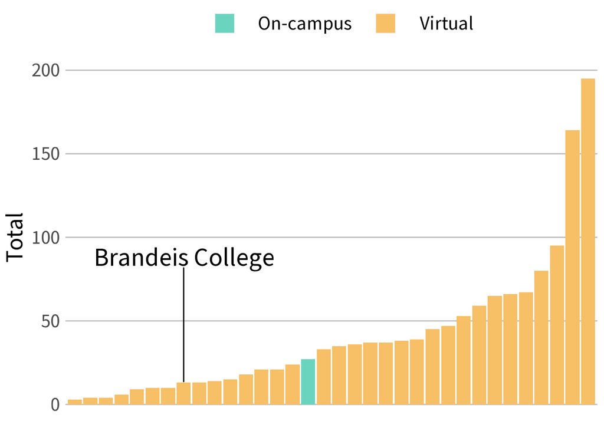

Summary

| N | 34 |
| --- | --- |
| Mean | 41 |
| Median | 34 |
| Max | 195 |
| Min | 3 |
| Brandeis College | 13 |

## Budget

### Total Available Funding

What do we do about Amherst? 7936792 isn’t obviously wrong.

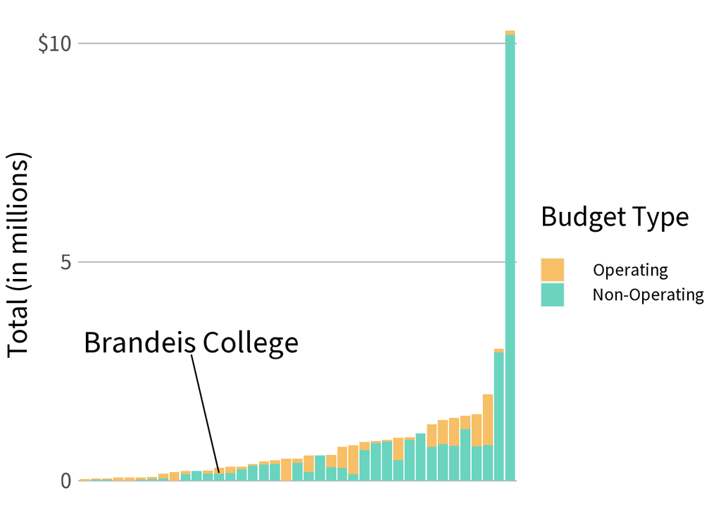

Summary

Total (operating and non-operating)

| N | 39 |
| --- | --- |
| Mean | 929,724 |
| Median | 501,376 |
| Max | 10,297,350 |
| Min | 34,000 |
| Brandeis College | 298,000 |

### Endowed Funds

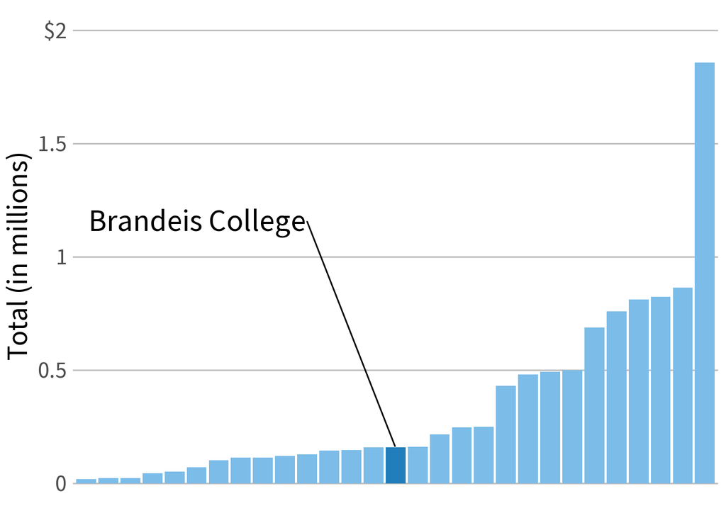

Summary

| N | 29 |
| --- | --- |
| Mean | 345,813 |
| Median | 159,000 |
| Max | 1,857,999 |
| Min | 19,101 |
| Brandeis College | 159,000 |

### Expendable Gifts

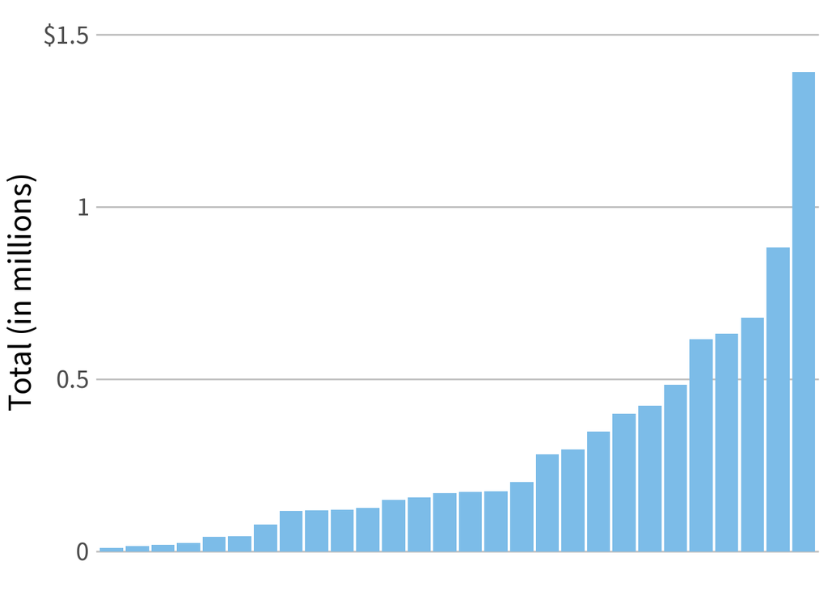

Summary

| N | 28 |
| --- | --- |
| Mean | 292,774 |
| Median | 171,887 |
| Max | 1,392,667 |
| Min | 10,623 |
| Brandeis College | 0 |

## Appendix

### Write-In Responses

#### Conferences

Career Leadership Collective, Career Leadership Collective, ASCN, CLASIC, Career Leadership Collective, Delaware Valley Career Planners - a local group, NetVUE, LACN :), NEAR, CASE, ACSN, CEIA - Cooperative Education & Internship Association, LACN, Handshake, National Student Employment Association, NACADA, LACN!, National Student Employment Association, Washington State Association of Student Employment Administrators, Career leadership Collective, MN Specific Consortia, None typically, Career Leadership Collective, LACN, Minnesota College and University Career Services Association, FGLI Consortium, NECOME, CLC

#### Undergraduate Services

Preprofessional/Graduate School Advising, Internship grant program, campus fellowship for unDACAmented students, Skill Development, Recent alumni career advising, career development, career exploration, opportunity funding, academic internship, document review, Career Exploration, pre-professional/Pathways advising, Strengths Coaching, resume/cover letter, job/internship search advising, Academic Advising & Academic Probationary Programs, State Work-Study, Connection to Alumni Mentores, Networking, Job Search, Documentation Review, Entrepreneurship, Dedicated post-graduation planning for FLGI students, business advising, STEM advising, career exploration, housing/budgeting

#### Undergraduate Programs

Events with our alumni board, Life Skills Programs, virtual career conference, recorded alumni interviews, Small scale/niche virtual career fair, online noncredit course, Career Launch is an alumni/student networking event that we offer.

#### Graduate Services

Document review, on-campus job search, same as what is offered to undergraduates